# Ayudantía III: Regresión Simple

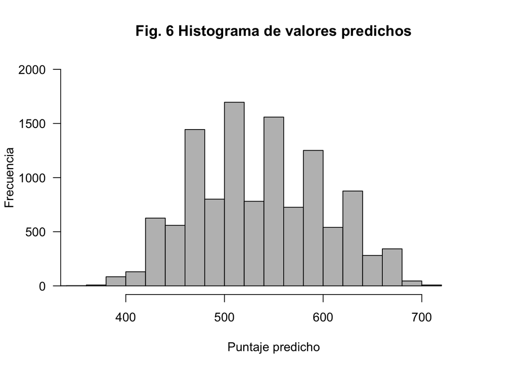

```r
#Generamos un histograma de calidad
hist(psu_sample$predict,
     main="Fig. 6 Histograma de valores predichos",
     ylab = "Frecuencia",
     xlab="Puntaje predicho",
     border="black",
     col = "gray",
     xlim=c(350,750),
     ylim=c(0,2000),
     las=1,
     breaks=20)
```

**9. Calcule los residuos de la regresión anterior. Calcule la correlación y grafique la relación entre los valores predichos y los residuos. ¿Cómo se explican estos resultados ¿Cuáles son las observaciones de mayor y menor residuo?**

```r
#Estimamos los residuos
#Manualmente
psu_sample$residuo <- psu_sample$mate - psu_sample$predict
#Lo podemos extraer de nuestra regresión
psu_sample$residuo <- residuals(m1)
#Revisamos nuestra base de datos
head(psu_sample)
```

```
##   mate x_nem  predict   residuo
## 1  499    50 436.9283  62.07166
## 2  656    58 543.6982 112.30177
## 3  569    59 557.0445  11.95554
## 4  513    52 463.6208  49.37919
## 5  391    50 436.9283 -45.92834
## 6  644    57 530.3520 113.64801
```

```r
#Correlación de valores predichos y residuos
cor(psu_sample$predict, psu_sample$residuo)
```

```
## [1] -0.000000000000000007417625
```

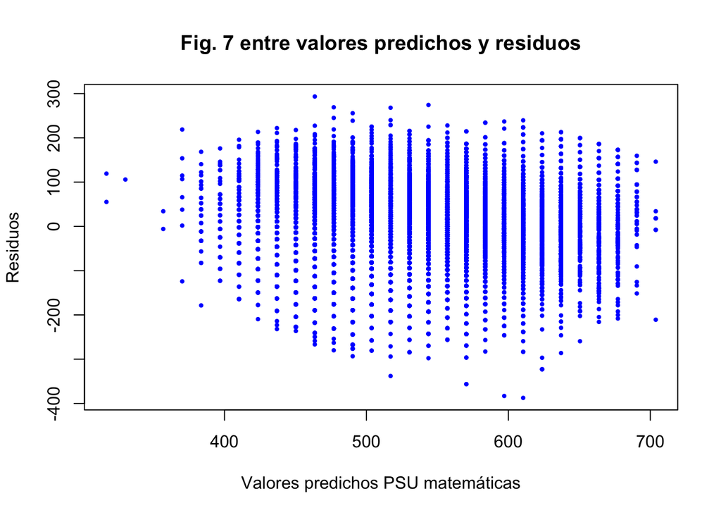

```r
#Gráfico entre valores predichos y residuos
plot(psu_sample$predict, psu_sample$residuo,
     col="blue", pch = 19, cex = 0.3, lty = "solid", lwd = 2,
     main = "Fig. 7 entre valores predichos y residuos",
     ylab = "Residuos",
     xlab = "Valores predichos PSU matemáticas")
abline(lm(predict ~ residuo,data=psu_sample), col="red")
```

```r
#Generamos una nueva columna con los residuos en valor absoluto
min(abs(psu_sample$residuo))
```

```
## [1] 0.03295103
```

```r
max(abs(psu_sample$residuo))
```

```
## [1] 387.4294
```

```r
psu_sample$absres <- abs(psu_sample$residuo)
#Identificamos la observación con menor residuo
minres <- psu_sample %>%
  filter(absres==min(psu_sample$absres))
#Identificamos la observación con mayor residuo
maxres <- psu_sample %>%
  filter(absres==max(psu_sample$absres))

#Podemos tener una idea general de nuestros residuos:
?arrange #Nos permite ordenar una base de datos
psu_sample <- arrange(psu_sample, absres)
brief(psu_sample)
```

```
## 11762 x 5 data.frame (11757 rows omitted)
##       mate x_nem  predict       residuo       absres
##        [n]   [n]      [n]           [n]          [n]
## 1      477    53 476.9670    0.03295103   0.03295103
## 2      477    53 476.9670    0.03295103   0.03295103
## 3      477    53 476.9670    0.03295103   0.03295103
## . . .
## 11761  214    62 597.0832 -383.08317059 383.08317059
## 11762  223    63 610.4294 -387.42940633 387.42940633
```

**10. Mencione una variable no observada que podría estar sesgando las estimaciones OLS al no ser incluida en el modelo. ¿Por qué se produciría este sesgo?**

Algunas variables no observadas que podrían estar sesgando nuestros resultados son: educación de la padre/madre, tipo de dependencia del establecimiento (municipal/particular subvencionado/privado), género. No considerar estas variables estarian omitiendo explicaciones alternaticas en los resultados en la PSU de matemáticas, por lo tanto se estaría obteniendo un coeficiente sesgado.

**¿Qué podemos hacer?**

# **Ejemplos**

## Tabla

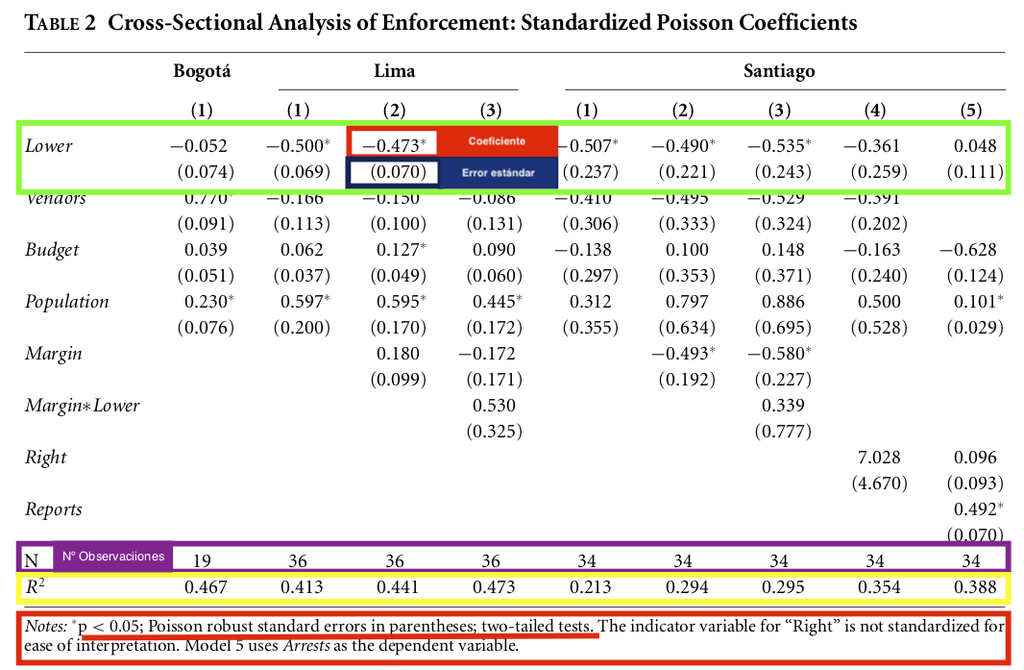

## Gráfico

Este es el gráfico que deben replicar para el ejercicio. No olviden:

- Nombrar la figura
- Etiquetar ejes
- Agregar una nota con información relevante: Nº de observaciones, significancia estadística, etc.

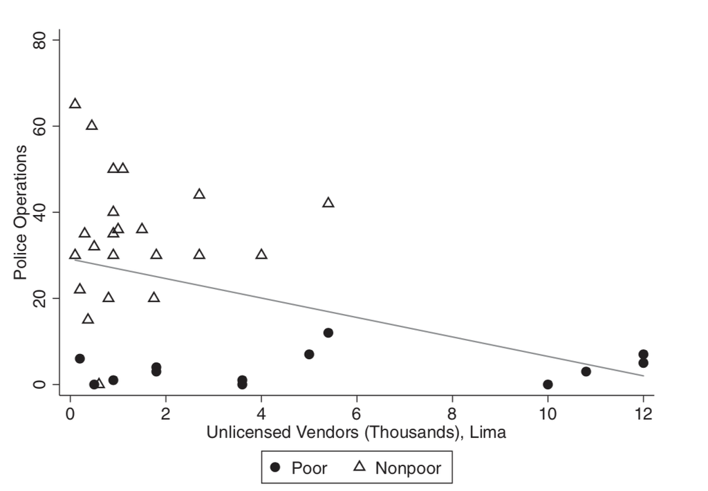

# **Referencias**

## Libro base de contenidos:

[Wooldridge, Jeffrey M. (2009). Introducción a la econometría: un enfoque moderno. 4a edición. Mé́xico: Cengage Learning.](https://www.dropbox.com/sh/t0s4r6yuzgcwt10/AAB9DxspiUmAqihGAITmhQpca?dl=0)

- Caps 2.1- 2.4 y 2.6 para regresión simple

[figure not shown]

## Libro base del curso para el uso R

[Fox, John y Sanford Weisberg (2019). An R Companion to Applied Regression. Third Edition. SAGE.](https://www.dropbox.com/sh/t0s4r6yuzgcwt10/AAB9DxspiUmAqihGAITmhQpca?dl=0)

- Caps 1 y 2.
- Gráficos: p.134 - p.138

[figure not shown]

## Ayudantías

Puedes encontrar las carpetas con las ayudantías en pdf y bases de datos en el siguiente [Link](https://github.com/JDConejeros/SOL201S_Datos_3)

La próxima ayudantía veremos:

- Control estadístico
- Introducción al modelo de regresión múltiple